# Predicting Potential Possibilty of Commit Suicide

## 4. Feedback...

#### 1. 험난한 주제선정과정

원래는 주식, 비트코인으로 하려고 했습니다.  
하지만 프로젝트를 진행하기에는 경제적인 지식이 두명 모두 부족했고, 이런 지식들을 보충하면서 프로젝트를 진행하기에는 시간이 촉박했습니다.  
또한 주식 비트코인 예측을 하려면 머신러닝을 통한 학습이 필요했고, 이를 keras를 사용해서 인터넷에 공유된 소스를 참고하여 진행해 보았습니다.  
잘 따라해서 막상 신기한 결과값을 얻기는 했습니다. 하지만 생각해보니 이것은 스스로 하는 활동이 아니고, 의미가 전혀 없다고 생각했습니다.  
또한 주식과 비트코인 값에 영향을 미치는 독립변수가 다양하지 않고 사실은 크게 규칙성이 없는 데이터에 의해서 값이 변동된다는 사실을 알았습니다.

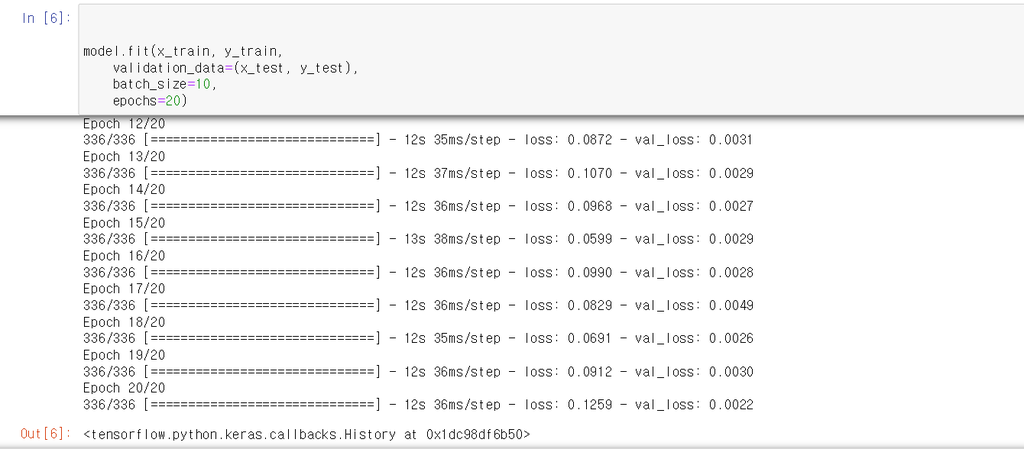

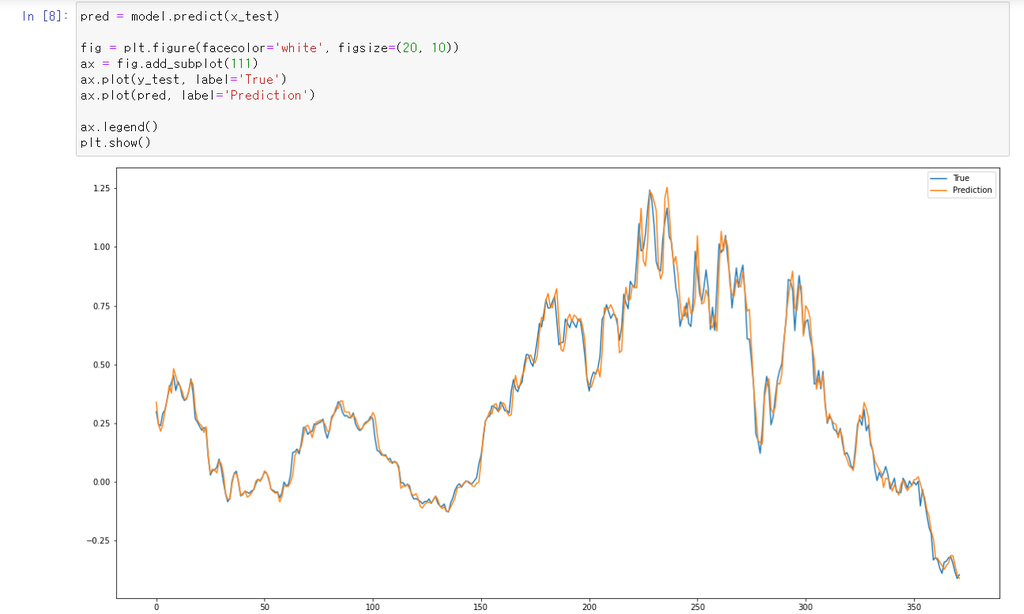

이런 문제점들을 직면하고 주제를 형량 예측으로 바꾸었습니다.  
하지만 개인정보보호특성상 개인이 일으킨 범죄와 선고 받은 형량을 제공하는 데이터셋은 없었습니다.  
이는 한국뿐만 아니라 여러 나라를 찾아보아도 정보를 제공하는 곳은 잘 없었습니다.  
비슷한 다른 주제를 고민하던중에 미국 데이터 공유 사이트에서 꽤 흥미로운 데이터를 발견했습니다.  
이는 일어난 범죄수와 어떤 유형의 범죄인지에 대한 비율, 성별 비율, 나이 비율, 술을 마신 가해자의 비율 등 전반적인 데이터들에 관한 비율이었습니다.  
저희 팀은 총 일어난 범죄수와 여러 가지 비율을 통해 전체 수를 직접 구해봄으로써 데이터 셋을 직접 만들었습니다.  
예를 들어 총 범죄수가 56000명이고 남자가 80%를 차지한다면, 56000개의 수를 뽑고 그 중에 80%는 남자로 20%는 여자로 지정한 다음  
무작위로 섞은 다음 총 56000개의 row를 가진 데이터셋을 만들었습니다.  
사실 무작위로 섞으면 데이터에서 의미를 찾는 일은 의미가 없어집니다.  
하지만 저희 팀은 만약 제대로 된 데이터셋을 확보한다면 충분히 실현 가능한 프로젝트를 진행할 수 있었기 때문에, 데이터가 실제 세계와 맞지 않더라도 해볼 가치가 있던 프로젝트라고 생각했습니다.  
여러 변수들에서 비율을 구하고 그를 무작위로 대입하여 꽤 그럴듯한 데이터 프레임을 만들 수 있었습니다.

```python
# Robbery 56933 / sex , age, drinking condition(offenders), drinking condition(victims) ,
#                   recognization of offenders, existence of another person accompanying the victim
```

```python
#sex
# Male 95.28% Female 1.88% BMF 2.83
# Male 54245 Female 1077 BMF 1611

#age
# Late teen 4897 Twenties 4783 Thirties 7696 Forties 13532 Fifties 15980 sixties to eighties 10025

#drinking condition(offenders) -> dont know 는 절반으로
# Yes 50.835% No 49.165%
# Yes 28942 No 27991

#drinking condition(victims) -> dont know 는 절반으로
# Yes 34.895% No 65.105%
# Yes 19867 No 37066

#recognization of offenders
# Yes 78% No 22%
# Yes 44408 No 12525

#existence of another person accompanying the victim
# Yes 33.095% No 66.905%
# Yes 18842 No 38091
```

```python
a_list = []
b_list = []
c_list = []
d_list = []
e_list = []
f_list = []
z_list = []


a = np.arange(0,56933)
idx = np.arange(a.shape[0])
np.random.shuffle(idx)

# sex
for i in range(len(idx)):
    if idx[i] < 54245:
        a_list.append("M")
    elif 54245<= idx[i] < 55322:
        a_list.append("F")
    else:
        a_list.append("BMF")

#print(a_list)

# age
for i in range(len(idx)):
    if idx[i]<4907:
        b_list.append(np.random.randint(15,19))
    elif 4907 <= idx[i]<9700:
        b_list.append(np.random.randint(20,29))
    elif 9700 <= idx[i]<17396:
        b_list.append(np.random.randint(30,39))
    elif 17396 <= idx[i]<30928:
        b_list.append(np.random.randint(40,49))
    elif 30928 <= idx[i]<46908:
        b_list.append(np.random.randint(50,59))
    elif 46908 <= idx[i]<56933:
        b_list.append(np.random.randint(60,89))

#print(b_list)

for k in range(len(idx)):
    if idx[k] < 28942:
        c_list.append(1)
    else:
        c_list.append(0)

#print(c_list)

for k in range(len(idx)):
    if idx[k] < 19867:
        d_list.append(1)
    else:
        d_list.append(0)

#print(d_list)

for k in range(len(idx)):
    if idx[k] < 44408:
        e_list.append(1)
    else:
        e_list.append(0)

#print(e_list)

for k in range(len(idx)):
    if idx[k] < 18842:
        f_list.append(1)
    else:
        f_list.append(0)

#print(f_list)


for i in range(len(idx)):
    if idx[i] < 22130:
        z_list.append(1)
    elif 22130<= idx[i] < 56933:
        z_list.append(0)

#print(z_list)
```

```python
df1 = pd.DataFrame(a_list).rename(columns = {0: "sex"})
df2 = pd.DataFrame(b_list).rename(columns = {0: "age"})
df3 = pd.DataFrame(c_list).rename(columns = {0: "drinking_offender"})
df4 = pd.DataFrame(d_list).rename(columns = {0: "drinking_victims"})
df5 = pd.DataFrame(e_list).rename(columns = {0: "recognization_of_offenders"})
df6 = pd.DataFrame(f_list).rename(columns = {0: "existence_of_accompanying_victims"})
df7 = pd.DataFrame(z_list).rename(columns = {0: "arrest_rate"})
df_fin = pd.concat([df1, df2, df3, df4, df5, df6, df7], axis = 1)
df_fin
```

|  | sex | age | drinking_offender | drinking_victims | recognization_of_offenders | existence_of_accompanying_victims | arrest_rate |
| --- | --- | --- | --- | --- | --- | --- | --- |
| 0 | F | 63 | 0 | 0 | 0 | 0 | 0 |
| 1 | M | 30 | 1 | 1 | 1 | 1 | 1 |
| 2 | M | 60 | 0 | 0 | 0 | 0 | 0 |
| 3 | M | 30 | 1 | 1 | 1 | 1 | 1 |
| 4 | M | 57 | 0 | 0 | 1 | 0 | 0 |
| ... | ... | ... | ... | ... | ... | ... | ... |
| 56928 | M | 52 | 0 | 0 | 1 | 0 | 0 |
| 56929 | M | 45 | 1 | 0 | 1 | 0 | 1 |
| 56930 | M | 28 | 1 | 1 | 1 | 1 | 1 |
| 56931 | M | 71 | 0 | 0 | 0 | 0 | 0 |
| 56932 | M | 52 | 0 | 0 | 1 | 0 | 0 |

56933 rows × 7 columns

```python
lm_model1 = smf.ols("arrest_rate ~ sex + age + drinking_offender + drinking_victims + recognization_of_offenders + existence_of_accompanying_victims",data = df_fin).fit()
```

```python
lm_model1.summary()
```

OLS Regression Results

| Dep. Variable: | arrest_rate | R-squared: | 0.874 |
| --- | --- | --- | --- |
| Model: | OLS | Adj. R-squared: | 0.874 |
| Method: | Least Squares | F-statistic: | 5.663e+04 |
| Date: | Tue, 08 Jun 2021 | Prob (F-statistic): | 0.00 |
| Time: | 16:19:23 | Log-Likelihood: | 19191. |
| No. Observations: | 56933 | AIC: | -3.837e+04 |
| Df Residuals: | 56925 | BIC: | -3.829e+04 |
| Df Model: | 7 |  |  |
| Covariance Type: | nonrobust |  |  |

|  | coef | std err | t | P>\|t\| | [0.025 | 0.975] |
| --- | --- | --- | --- | --- | --- | --- |
| Intercept | 0.0021 | 0.008 | 0.260 | 0.795 | -0.014 | 0.018 |
| sex[T.F] | 6.26e-06 | 0.007 | 0.001 | 0.999 | -0.013 | 0.013 |
| sex[T.M] | -0.0001 | 0.005 | -0.031 | 0.975 | -0.009 | 0.009 |
| age | -2.905e-05 | 9.55e-05 | -0.304 | 0.761 | -0.000 | 0.000 |
| drinking_offender | 0.2491 | 0.002 | 102.441 | 0.000 | 0.244 | 0.254 |
| drinking_victims | 0.7506 | 0.006 | 131.871 | 0.000 | 0.739 | 0.762 |
| recognization_of_offenders | -0.0005 | 0.003 | -0.173 | 0.863 | -0.006 | 0.005 |
| existence_of_accompanying_victims | -0.0005 | 0.006 | -0.083 | 0.934 | -0.012 | 0.011 |

| Omnibus: | 35590.513 | Durbin-Watson: | 2.005 |
| --- | --- | --- | --- |
| Prob(Omnibus): | 0.000 | Jarque-Bera (JB): | 404368.213 |
| Skew: | 2.902 | Prob(JB): | 0.00 |
| Kurtosis: | 14.695 | Cond. No. | 665. |

Warnings:  
[1] Standard Errors assume that the covariance matrix of the errors is correctly specified.

```python
lm_model2 = smf.glm("arrest_rate ~ drinking_offender + drinking_victims + recognization_of_offenders",data = df_fin,family = sm.families.Binomial()).fit()
```

```python
lm_model2.summary()
```

Generalized Linear Model Regression Results

| Dep. Variable: | arrest_rate | No. Observations: | 56933 |
| --- | --- | --- | --- |
| Model: | GLM | Df Residuals: | 56929 |
| Model Family: | Binomial | Df Model: | 3 |
| Link Function: | logit | Scale: | 1.0000 |
| Method: | IRLS | Log-Likelihood: | -5096.9 |
| Date: | Tue, 08 Jun 2021 | Deviance: | 10194. |
| Time: | 16:19:24 | Pearson chi2: | 9.08e+03 |
| No. Iterations: | 29 |  |  |
| Covariance Type: | nonrobust |  |  |

|  | coef | std err | z | P>\|z\| | [0.025 | 0.975] |
| --- | --- | --- | --- | --- | --- | --- |
| Intercept | -30.5661 | 2.35e+04 | -0.001 | 0.999 | -4.61e+04 | 4.61e+04 |
| drinking_offender | 29.4641 | 2.12e+04 | 0.001 | 0.999 | -4.14e+04 | 4.15e+04 |
| drinking_victims | 31.6681 | 1.87e+04 | 0.002 | 0.999 | -3.66e+04 | 3.66e+04 |
| recognization_of_offenders | 5.694e-09 | 3.16e+04 | 1.8e-13 | 1.000 | -6.2e+04 | 6.2e+04 |

다 만들고 나서야 지금까지 했던 프로젝트 진행 과정이 사실 아무 의미가 없는 모델을 만든것에 지나치지 않았다는 사실을 알게 되었고, 한번 더 주제를 바꿀 생각을 하게 됩니다.

#### 2. 아쉬웠거나 느낀점

최종 프로젝트에서는 국민건강영양조사에 있던 많은 데이터들을 사용하고 싶었습니다. 하지만 데이터가 너무 많아서 자살율과 관련되어 있을 것이라고 예측되는 데이터들만 추출해서 사용하였습니다.  
사실 물 섭취량, 최종 학력, BMI 등 딱히 자살율과 크게 관련은 없지만 뭔가 관련이 있을 수도 있다고 생각한 여러 독립변수들이 있었습니다.  
하지만 이런 변수들을 모두 하나하나 확인해보기에는 너무 데이터가 많았고 시간도 촉박했고, 저희의 데이터 가공 능력도 부족했습니다. 이번 프로젝트 발표 후에 아마도 여름방학에 저희가 자살과 관련되어있다고 생각한 변수 외에도 여러 가지 다른 변수들을 사용해서  
모델을 만들어보고 싶고, 분명히 예를 들어 우리가 "와 이게 자살과 관련이 있네?" 라고 생각할 만한 독립변수가 있을 것이라고 생각합니다.  
그런 변수들을 찾아서 예상치 못한 부분에 대한 통찰력도 얻고 싶습니다.  
또한 이번 프로젝트 후에 교수님의 피드백에 힘입어 더 정확한 모델과 그 예측값을 얻을 수 있다면 이를 에브리타임 게시판에 올려서  
부산대학교 사용자들의 흥미를 끌면 좋겠다는 생각을 했습니다.  
또한 사용자들의 응답 정보 데이터를 얻을 수 있는 방법을 찾아서 부산대학교 학생들의 결과값을 분석해보고 싶습니다.

최종모델이 결정계수가 낮은것에 대하여...  
결정계수의 의미는 이 모델이 얼마나 종속변수와 독립변수간에 설명을 잘하는가 에 대한 값인데,  
이 값이 0.474밖에 나오지 않아 잘맞지 않다고 생각할 수 있습니다.  
하지만 p값은 대다수 0.05이하로 나왔고 추가로 aic 값이 유별나게도 저희가 설정한 모든 독립변수를 넣었을때 가장 작은 값이 나왔고  
결정계수에 대한 것도 aic 경우와 같이 설정한 모든 독립변수를 다 넣었을때가 더 좋은 결과가 나왔습니다.  
이러한 점에서 저희의 최종모델의 결정계수 값이 0.7이상에 미치지 못한것에 아쉬움이 있으나 이는 4단계로 분리된 데이터 때문이라고 생각합니다.  
저희가 예측을 할때는 0 ~ 100 이라는 연속형 수치로 넣지만, 데이터에 존재하는 것은 단순히 25, 50, 75, 100 총 4가지 데이터이므로  
이에 대해서 데이터와 모델간에 설명하는 것이 조금 부실하였다고 생각합니다.